# Assignment 5 - K-means

Author

Samantha Wan

# 1 Goal of this assignment

The goal of this assignment is for you to **explore the k-means algorithm** learned in class.

In specific, you will be asked to:  
- Use a different number of k than what we did in class,  
- Validate the results of the new model, and  
- Compare your results with those found in class

# 2 Instructions

You will first need to watch (and code along with) the following k-means video:

- k-means lab: https://youtu.be/GFgMp5tYiMU?si=CI0E-2r-cYZLGVL1 (start from beginning of video, watch till the 01:10)
- The partial script for the video above is in our GitHub repository, 04-classcode, **02-24_multivar_kmeans_partial.qmd**. Move the script mentioned above into the `code` subfolder of your `06_multivar` project

**AFTER watching the video and developing the code in class**, then start working on this HW assignment (instructions below): - Move this script into the `code` subfolder of your `06_multivar` project  
- On this script, fill your name under the `title` section of the YAML  
- Go back to the class k-means script, choose a different number of k than what we did in class, and run it.

**Setup**

```r
#install.packages("ggcorrplot")
#install.packages("factoextra")
#install.packages("ggpmisc")

library(tidyverse)
library(ggcorrplot)
library(broom)
library(car)
library(factoextra)
library(ggpmisc)
```

```r
weather <- read.csv("../data/weather_monthsum.csv")

head(weather)
```

```
  year                site strength_gtex mean_dayl.s_Jan mean_srad.wm2_Jan
1 1980           Altus, OK          25.3         35872.6             242.4
2 1980 Ames Plantation, TN          27.2         35743.3             214.8
3 1980         Artesia, NM          26.0         36359.0             279.2
4 1980          Auburn, AL          24.8         36420.2             239.5
5 1980        Beeville, TX          24.5         37494.3             277.0
6 1980      Belle Mina, AL          28.1         35872.6             223.5
  mean_tmax.c_Jan mean_tmin.c_Jan mean_vp.pa_Jan sum_prcp.mm_Jan
1            10.2            -1.5          535.7            61.6
2             9.2             0.2          636.2           106.6
3            13.4            -2.4          387.0            29.8
4            13.9             2.9          787.8           119.4
5            19.9             7.2         1054.8           105.0
6             9.7             0.7          662.4           142.4
  mean_dayl.s_Feb mean_srad.wm2_Feb mean_tmax.c_Feb mean_tmin.c_Feb
```

[output cut: 118 more lines]

```r
#Selecting only numeric variables and normalizing the data
weather_n <- weather %>%
  dplyr::select(-c(year:strength_gtex))

weather_norm  <- weather_n %>%
  mutate(across(everything(), ~scale(.x)))
```

# 3 Questions

## 3.1 1. What number of k did you select? Why?

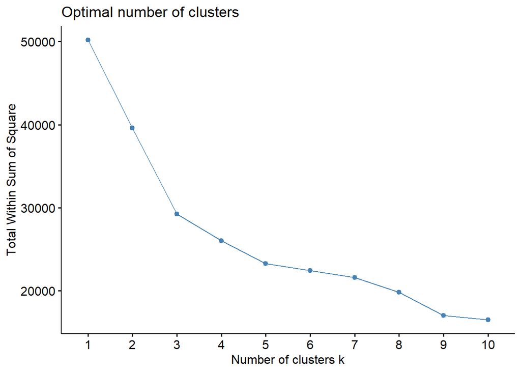

```r
# Elbow and Silhouete Methods for visualizing dataset to determine K-value
fviz_nbclust(weather_norm,
             method = "wss",
             k.max = 10,
             FUNcluster = kmeans
             )
```

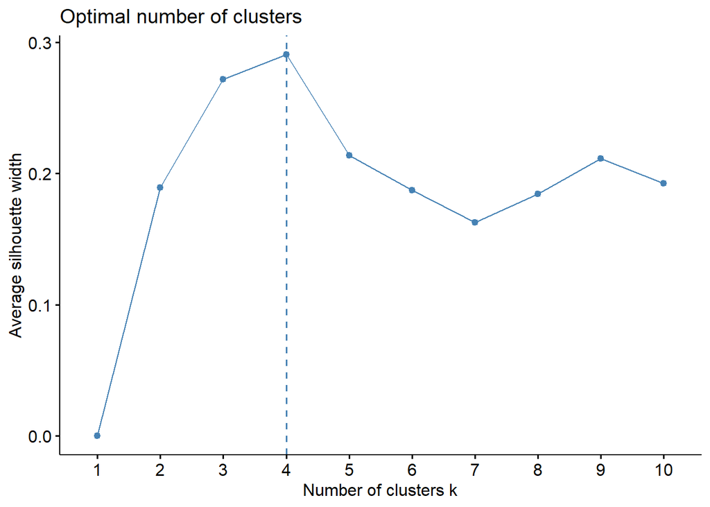

```r
fviz_nbclust(weather_norm,
             method = "s",
             k.max = 10,
             FUNcluster = kmeans
             )
```

*I selected 3 k means clusters because based on the two visualization’s 3 would be the next best choice to 4 clusters. Based on the Within Sum of Squares (elbow method) we see a more moderate drop between 3 and 4 than we did between 1 & 2 and 2 & 3. Then when looking at the Silhouette method 3 had the second highest peak.*

```r
mod_km3 <- kmeans(weather_norm,
                  centers = 3,
                  nstart =10
                  )

mod_km3
```

```
K-means clustering with 3 clusters of sizes 108, 253, 337

Cluster means:
  mean_dayl.s_Jan mean_srad.wm2_Jan mean_tmax.c_Jan mean_tmin.c_Jan
1       1.7190360         0.6918031       1.1058209       1.3197076
2      -0.1801910         0.5670544       0.2335246      -0.2719336
3      -0.4156308        -0.6474169      -0.5297044      -0.2187810
  mean_vp.pa_Jan sum_prcp.mm_Jan mean_dayl.s_Feb mean_srad.wm2_Feb
1     1.31510797      -0.1334977       1.7105026         0.2832499
2    -0.65554849      -0.6529598      -0.1762743         0.6356431
3     0.07068874       0.5329869      -0.4158365        -0.5679783
  mean_tmax.c_Feb mean_tmin.c_Feb mean_vp.pa_Feb sum_prcp.mm_Feb
1       0.9501809       1.3345351      1.2497965      -0.2422610
2       0.2950628      -0.2666156     -0.7074464      -0.6427831
3      -0.5260250      -0.2275254      0.1305814       0.5602027
```

[output cut: 90 more lines]

## 3.2 2. How many observations are there in each cluster?

```r
weather %>%
  mutate(cluster = mod_km3$cluster) %>%
  group_by(cluster) %>%
  tally()
```

```
# A tibble: 3 × 2
  cluster     n
    <int> <int>
1       1   108
2       2   253
3       3   337
```

*There were 108 observations in cluster 1, 253 in cluster 2, and 337 in cluster 3.*

## 3.3 3. Using the `fviz_cluster()` function, import here the original plot with k=4 did in class, and the new plot with the number of k you selected for this exercise. How do they visually compare? Which one seems to be a better choice, and why?

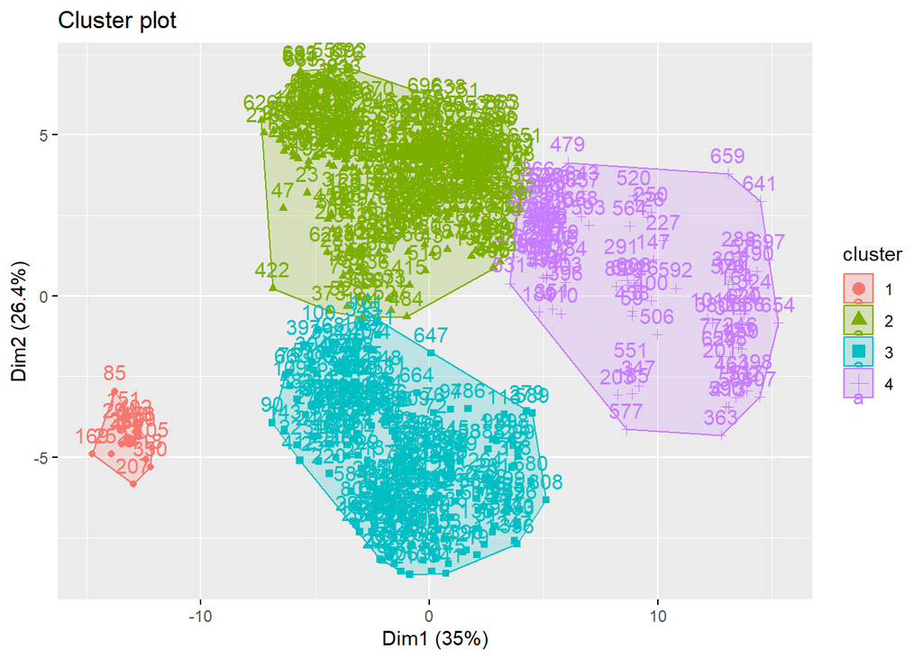

```r
mod_km4 <- kmeans(weather_norm,
                  centers = 4,
                  nstart =10
                  )
fviz_cluster(mod_km4,
             data = weather_norm
             )
```

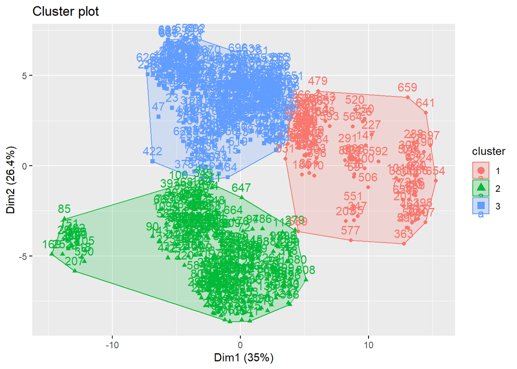

```r
fviz_cluster(mod_km3,
             data = weather_norm
             )
```

*I still think that 4 was the optimal choice when looking at these clusters using the K means method of clustering. When we look at the visualization of 3 clusters its apparent that there is another cluster to the far left that should be it’s own distinct cluster which is what we see when we cluster into 4 groups.*

# 4 Submitting your work

Once you have developed all the code and answers, make sure to Render this quarto file.

**Notes on rendering**:

- Make sure to render your work and inspect how the final html look like.
- If it does not look professional for whatever reason, then fix the issue, re-render it, recheck.
- Only send me your work once your html file looks professional.
  - **DO NOT** delete the file’s heading levels (# and ##). They set up the proper heading 1 and 2 levels, and I use them to guide my grading.
  - If a given chunk is also outputting warnings or messages, inhibit this behavior by changing the chunk options `message` and `warning` to `FALSE` (I’ll demo this in a moment).
  - If, after rendered, 2 lines of text are connected and you wish to “break line” between them, add 2 extra spaces after the first one (I’lld demo this in a moment).

After rendering, an .html file will be created on your `code` folder.

Rename this file to `Assignment-05-kmeans-LASTNAME.html`.

For ex., mine would be `Assignment-05-kmeans-Bastos.html`.

Submit your work by uploading the **html** file to **eLC Assignment #5 - K-means** by Monday March 2nd 11:59 pm.